# Биометрия

Основы информационной безопасности

Мальянц Виктория Кареновна

1132246740@rudn.ru

Российский университет дружбы народов

2026-04-12

## Докладчик

- Мальянц Виктория Кареновна
- НКАбд-03-24
- Студенческий билет 1132246740
- Компьютерные и информационные науки
- Российский университет дружбы народов
- https://github.com/victoriamalyants/

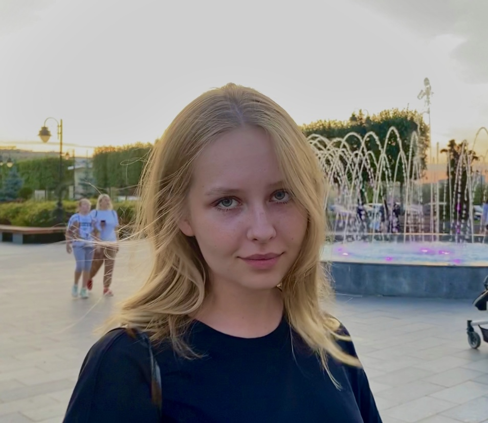

## Преподаватель

- Кулябов Дмитрий Сергеевич
- д.ф.-м.н., профессор
- профессор кафедры прикладной информатики и теории вероятностей
- Российский университет дружбы народов
- kulyabov-ds@rudn.ru
- https://yamadharma.github.io/ru/

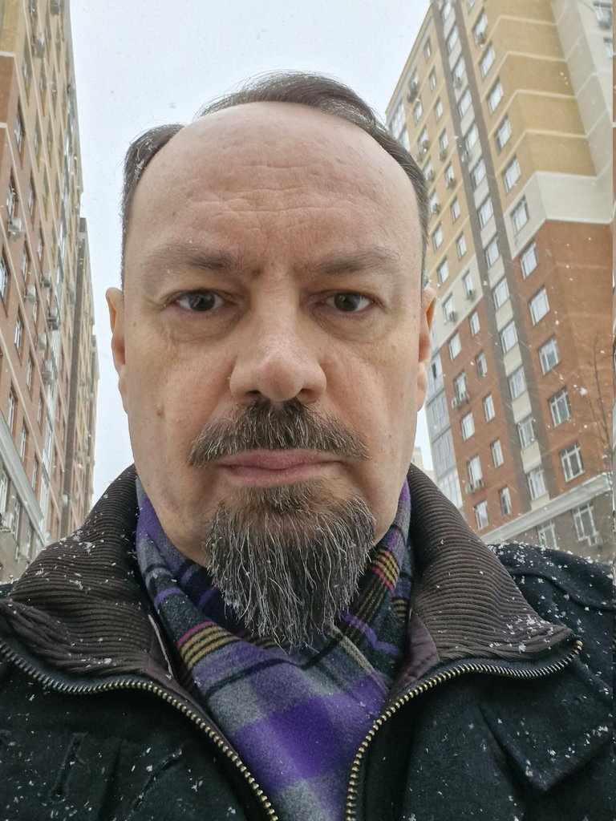

## Цели и задачи

- Изучить понятие биометрии
- Изучить виды биометрических данных
- Изучить принципы работы
- Изучить применение

## Введение

- Биометрия - это технология, которая использует уникальные физические или поведенческие характеристики человека для идентификации личности.
- Актуальность данной темы обусловлена возрастающими требованиями к надежности систем аутентификации в условиях цифровизации.
- Биометрические технологии представляют собой активно развивающуюся область, находящуюся на стыке компьютерного зрения, информационной безопасности и распознавания образов. Существует множество различных методов, общим для них является необходимость решения задачи преобразования биологического признака в цифровой шаблон с последующим сравнением.

## Виды биометрических данных

- Биометрические данные делятся на два вида: физиологические и поведенческие. Существует мультимодальная биометрия - это подход к биометрической идентификации и аутентификации, который предполагает использование двух и более различных типов данных для повышения точности и надежности систем распознавания.
- Рассмотрим подробнее виды биометрических данных.

## Виды биометрических данных

- Физиологические:
- Отпечатки пальцев
- Геометрия лица
- Сетчатка глаза
- Радужная оболочка
- ДНК
- Вены ладони
- Вены пальца

## Виды биометрических данных

- Поведенческие:
- Динамика подписи
- Голос
- Походка
- Клавиатурный почерк

## Принципы работы

- Выделим 6 этапов от сенсора до решения.
- Захват.
- Предобработка.
- Извлечение признаков.
- Создание биометрического шаблона.
- Сравнение.
- Принятие решения.

## Применение

- Электроника.
- Розничная торговля и сфера услуг.
- Финансовый сектор.
- Аэропорты.
- Корпоративный сектор.
- Здравоохранение.
- Транспорт.
- Образование.

## Заключение

- В современном мире биометрические технологии занимают ключевое место в системах идентификации и аутентификации личности. Биометрия использует уникальные, практические не поддающиеся подделке характеристики человека, что обеспечивает высокий уровень безопасности.